# Statistics in Python: Multiple Linear Regression

⇦ Back

**Linear regression** involves fitting a straight-line relationship to one group of continuous numerical data that has one dependent variable and at least one independent variable. If there is only one independent variable then it is **simple** linear regression whereas more than one independent variable makes it **multiple** linear regression. In other words:

- We need to have *continuous data* (ie numbers) that come from measurements, not from ratings or scores
- A straight-line *relationship* is fitted to this data. And there is only one group which means that there is no way to look at the differences between groups.
- There is at least one independent variable and all are *true* independent variables (meaning that all other variables are being controlled for and stay the same when the independent variable in question is being read)
- The shape of the data when plotted suggests that a *straight-line* relationship is appropriate, as opposed to a parabolic line or some other curve

If the above criteria are met then, as we can see from the flowchart below, linear regression is needed.

[interactive chart not shown]

**Simple** linear regression can be represented graphically on a 2D plot with the independent variable on the x-axis and the dependent variable on the y-axis. **Multiple** linear regression, if there are two independent variables, can be represented on a 3D plot with three axes: one independent variable on x, the other independent on y and the dependent variable on z (pointing upwards):

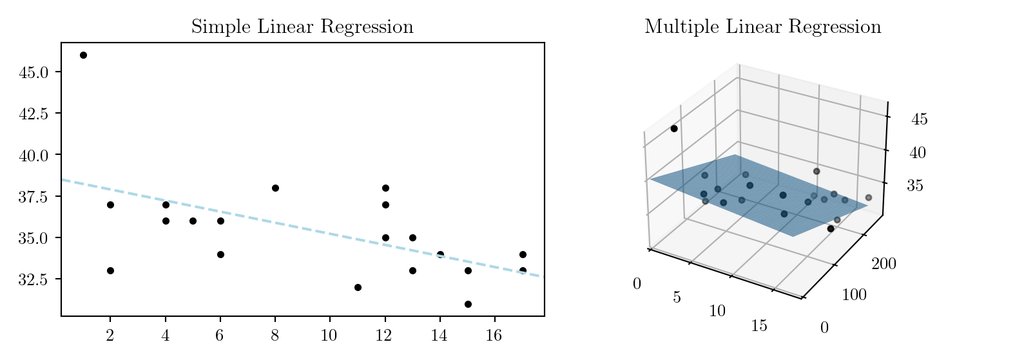

If there are **more than two** independent variables then it becomes difficult to represent the regression on a plot, but the idea is the same. Note that in the 2D plot the linear relationship is literally a straight line whereas in the 3D plot the linear relationship becomes a *surface* - a flat plane. It is a ‘plane-of-best-fit’ as opposed to a ‘line-of-best-fit’.

Conceptually, multiple linear regression can be thought of as simple linear regression performed once for each independent variable. If we take the multiple linear regression shown above in the figure on the right, rotate it and view it end-on from two sides we can see that it’s just two straight-line relationships:

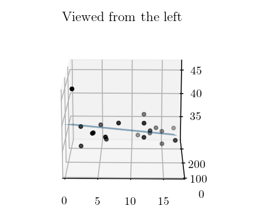

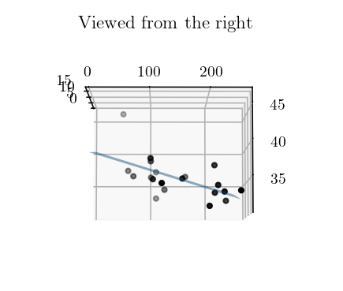

So multiple linear regression is *literally* linear regression done multiple times!

# 1 Packages

The code on this page uses the scikit-learn, Matplotlib, NumPy, SciPy, Pandas and Statsmodels packages. These can be installed from the terminal with:

```bash
$ python3.11 -m pip install sklearn
$ python3.11 -m pip install matplotlib
$ python3.11 -m pip install numpy
$ python3.11 -m pip install scipy
$ python3.11 -m pip install pandas
$ python3.11 -m pip install statsmodels
```

where `python3.11` corresponds to the version of Python you have installed and are using.

# 2 Example Data

For this example we’re going to use the Linnerud dataset from scikit-learn. This contains physical exercise data from 20 volunteers (middle-aged non-elite-athlete men) that can be used as *explanatory variables* (independent variables) to explain the *scalar response* or *target* (dependent variable) which, in this case, is physiological health.

In particular, this example will use the number of chin-ups and sit-ups completed by each volunteer (metrics of physical performance) as the independent variables, and the volunteers’ waist circumferences (metric of physiological health) as the dependent variable:

```python
from sklearn import datasets

# Load the dataset
linnerud = datasets.load_linnerud(as_frame=True)

# Extract the relevant data
xy = linnerud['data'][['Chins', 'Situps']]
z = linnerud['target']['Waist']

print(xy.join(z))
```

```
##     Chins  Situps  Waist
## 0     5.0   162.0   36.0
## 1     2.0   110.0   37.0
## 2    12.0   101.0   38.0
## 3    12.0   105.0   35.0
## 4    13.0   155.0   35.0
## 5     4.0   101.0   36.0
## 6     8.0   101.0   38.0
## 7     6.0   125.0   34.0
## 8    15.0   200.0   31.0
## 9    17.0   251.0   33.0
## 10   17.0   120.0   34.0
## 11   13.0   210.0   33.0
## 12   14.0   215.0   34.0
## 13    1.0    50.0   46.0
## 14    6.0    70.0   36.0
## 15   12.0   210.0   37.0
## 16    4.0    60.0   37.0
## 17   11.0   230.0   32.0
## 18   15.0   225.0   33.0
## 19    2.0   110.0   33.0
```

# 3 Exploring the Data

To make an initial decision as to what summary model to use, plot the raw data:

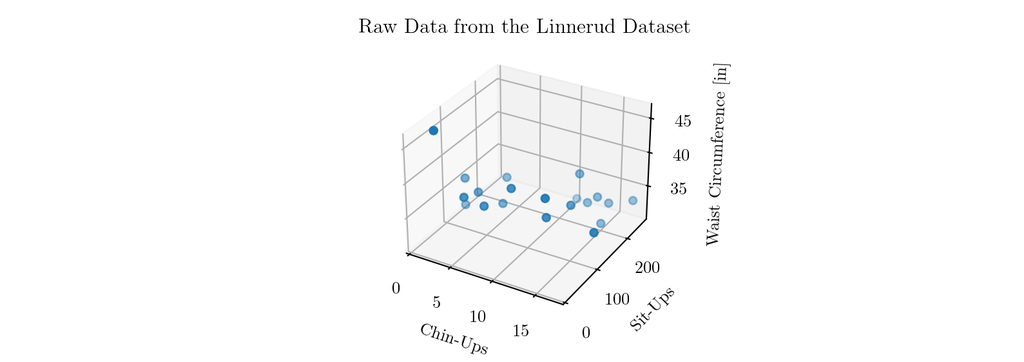

```python
import matplotlib.pyplot as plt

x = linnerud['data']['Chins']
y = linnerud['data']['Situps']
z = linnerud['target']['Waist']

# Plot
fig = plt.figure()
ax = fig.add_subplot(projection='3d')
ax.scatter(x, y, z)
ax.set_title('Raw Data from the Linnerud Dataset')
ax.set_xlabel('Chin-Ups')
ax.set_ylabel('Sit-Ups')
ax.set_zlabel('Waist Circumference [in]')
xlim = ax.get_xlim()
ylim = ax.get_ylim()
ax.set_xlim(0, xlim[1])
ax.set_ylim(0, ylim[1])
plt.show()
```

Note, when running this in Python we can actually get a 3D model to appear in a pop-up window. This can be moved around with the mouse to get a much better idea of how the data is spread around in space:

```python
import matplotlib

matplotlib.use('TkAgg')

plt.show()
```

This requires the ‘tkinter’ (Tk interface) package to be installed. To do this, run the following from the terminal:

```bash
$ sudo apt-get install python3-tk
```

In lieu of that, here’s the same data in two 2D plots:

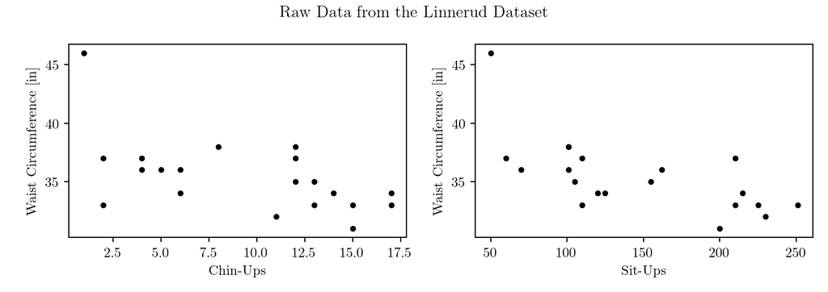

```python
# Make figures A7 in size
A = 7
plt.rc('figure', figsize=[2 * 46.82 * .5**(.5 * A), 33.11 * .5**(.5 * A)])

# Whole figure
fig = plt.figure()
plt.suptitle('Raw Data from the Linnerud Dataset')

# Left-hand plot
ax1 = fig.add_subplot(1, 2, 1)
ax1.scatter(x, z, c='k', s=10)
ax1.set_xlabel('Chin-Ups')
ax1.set_ylabel('Waist Circumference [in]')

# Right-hand plot
ax2 = fig.add_subplot(1, 2, 2)
ax2.scatter(y, z, c='k', s=10)
ax2.set_xlabel('Sit-Ups')
ax2.set_ylabel('Waist Circumference [in]')

plt.tight_layout()
plt.show()
```

A multiple linear regression model does indeed seem appropriate in this case because, for both independent variables, waist circumference roughly decreases as the variable increases.

# 4 Fitting the Model

The full 3D multiple linear regression model is represented by the equation z = β₁x + β₂y + α where:

- x and y are the **independent variables** (chin-ups and sit-ups)
- z is the **dependent variable** (waist circumference)
- β₁ and β₂ are the **coefficients** of the independent variables
- α is the **intercept** of the z-axis (the value of z when x and y are 0)
- β₁, β₂ and α together are the **parameters**
- The full equation z = β₁x + β₂y + α creates a **surface** when plotted on a 3D plot with axes x, y & z when the values of parameters β₁, β₂ and α are known

A *hypothesis test* is performed for each of the parameters. In each case, the null hypothesis is that the parameter in question is equal to zero and the alternative hypothesis is that it is not.

## 4.1 Using NumPy for the Parameter Estimations

NumPy contains the `np.linalg.lstsq()` function which performs least-squares optimisation. We can use this for linear regression, although our data needs to have a constant term added to it before it will work. You can do this with `xy['Constant'] = 1` before doing the optimisation:

```python
import numpy as np

# Independent variables
xy = linnerud['data'][['Chins', 'Situps']]
# Add a column with a constant
xy['Constant'] = 1
# Dependent variable
z = linnerud['target']['Waist']

# Perform multiple linear regression
returns = np.linalg.lstsq(xy, z, rcond=None)
```

Now we can extract the parameter estimations from the optimisation’s returns:

```python
# Get the parameters
params = returns[0]
# Get the coefficients
β1 = params[0]
β2 = params[1]
# Get the intercept
α = params[2]

# z = β₁x + β₂y + α
print(f'The full multiple linear regression model: z = {β1:-.3f}x {β2:=+7.3f}y {α:=+8.3f}')
```

```
## The full multiple linear regression model: z = -0.121x - 0.026y + 40.317
```

Now calculate the p-values and the 95% confidence interval:

```python
from scipy import stats as st

# Sum of squared residuals
# (this is returned from the np.linalg.lstsq() function)
sum_sq_residuals = returns[1]
# Degrees of freedom (sample size - number of parameters)
dof = len(xy) - len(params)
# Mean squared error
mse = sum_sq_residuals / dof
# Covariances of the parameters ('@'' is the dot product)
cov = mse * np.diagonal(np.linalg.inv(xy.T @ xy))
# Standard errors of the parameters
se = np.sqrt(cov)
# t-statistics associated with the parameters
t_statistics = params / se
# Two-tailed test
tails = 2
# Calculate the p-values
p_values = [tails * (1 - st.t.cdf(np.abs(t), dof)) for t in t_statistics]
# Significance level
alpha = 0.05
# Percent-point function (aka quantile function) of the t-distribution
t = st.t.ppf(1 - (alpha / tails), dof)
# Margin of error
d = t * se
# 95% confidence interval
upper_ci = params + d
lower_ci = params - d
```

Display the results:

```python
import pandas as pd

pd.set_option('display.max_columns', 20)
pd.set_option('display.width', 200)

# Display the results
output = [params, se, t_statistics, p_values, lower_ci, upper_ci]
index = ['Value', 'Standard Error', 't-Statistic', 'p-Value', 'Lower CI', 'Upper CI']
output = pd.DataFrame(output, index=index, columns=list(xy)).round(3)
output = output.T
output.insert(0, 'Parameter', ['β₁', 'β₂', 'α'])

print(output)
```

```
##          Parameter   Value  Standard Error  t-Statistic  p-Value  Lower CI  Upper CI
## Chins           β₁  -0.121           0.153       -0.789    0.441    -0.445     0.203
## Situps          β₂  -0.026           0.013       -2.000    0.062    -0.053     0.001
## Constant         α  40.317           1.476       27.322    0.000    37.204    43.430
```

## 4.2 Using SciPy for the Parameter Estimations

SciPy contains `optimize.curve_fit()` which also performs optimisation. You *don’t* need to add in the constant term but you *do* need to define the model as a function:

```python
from scipy import optimize


def fn(x, a, b, c):
    """z = β₁x + β₂y + α."""
    return a * x[0] + b * x[1] + c


# Independent variables
xy = linnerud['data'][['Chins', 'Situps']]
# Dependent variable
z = linnerud['target']['Waist']

# Perform multiple linear regression
popt, pcov = optimize.curve_fit(fn, xy.values.T, z)
```

Extract the parameter estimations:

```python
# Get the parameters
β1 = popt[0]
β2 = popt[1]
α = popt[2]

# z = β₁x + β₂y + α
print(f'The full multiple linear regression model: z = {β1:-.3f}x {β2:=+7.3f}y {α:=+8.3f}')
```

```
## The full multiple linear regression model: z = -0.121x - 0.026y + 40.317
```

Now calculate the p-values and the 95% confidence interval:

```python
# Re-format to align with NumPy
params = popt
xy['Constant'] = 1

# Covariances of the parameters
# (this is returned from the optimize.curve_fit() function)
cov = np.diagonal(pcov)
# Standard errors of the parameters
se = np.sqrt(cov)
# t-statistics associated with the parameters
t_statistics = params / se
# Two-tailed test
tails = 2
# Degrees of freedom (sample size - number of parameters)
dof = len(xy) - len(popt)
# Calculate the p-values
p_values = [tails * (1 - st.t.cdf(np.abs(t), dof)) for t in t_statistics]
# Significance level
alpha = 0.05
# Percent-point function (aka quantile function) of the t-distribution
t = st.t.ppf(1 - (alpha / tails), dof)
# Margin of error
d = t * se
# 95% confidence interval
upper_ci = params + d
lower_ci = params - d
```

Display the results:

```python
pd.set_option('display.max_columns', 20)
pd.set_option('display.width', 200)

# Display the results
output = [params, se, t_statistics, p_values, lower_ci, upper_ci]
index = ['Value', 'Standard Error', 't-Statistic', 'p-Value', 'Lower CI', 'Upper CI']
output = pd.DataFrame(output, index=index, columns=list(xy)).round(3)
output = output.T
output.insert(0, 'Parameter', ['β₁', 'β₂', 'α'])

print(output)
```

```
##          Parameter   Value  Standard Error  t-Statistic  p-Value  Lower CI  Upper CI
## Chins           β₁  -0.121           0.153       -0.789    0.441    -0.445     0.203
## Situps          β₂  -0.026           0.013       -2.000    0.062    -0.053     0.001
## Constant         α  40.317           1.476       27.322    0.000    37.204    43.430
```

## 4.3 Using Statsmodels’s API

Statsmodels actually provides three equivalent ways to perform optimisation via ordinary least-squares. The first is `OLS()` which, again, requires that you manually add a constant:

```python
import statsmodels.api as sm

# Independent variables
xy = linnerud['data'][['Chins', 'Situps']]
# Add a column with a constant
xy['Constant'] = 1
# Dependent variable
z = linnerud['target']['Waist']

# Perform multiple linear regression using ordinary least-squares
model = sm.OLS(z, xy)
# Fit the model
results = model.fit()
```

Statsmodels calculates *everything* in the background, so here are all our results:

```python
print(results.summary())
```

```
##                             OLS Regression Results
## ==============================================================================
## Dep. Variable:                  Waist   R-squared:                       0.437
## Model:                            OLS   Adj. R-squared:                  0.371
## Method:                 Least Squares   F-statistic:                     6.608
## Date:                Mon, 28 Aug 2023   Prob (F-statistic):            0.00753
## Time:                        00:06:06   Log-Likelihood:                -45.390
## No. Observations:                  20   AIC:                             96.78
## Df Residuals:                      17   BIC:                             99.77
## Df Model:                           2
## Covariance Type:            nonrobust
## ==============================================================================
##                  coef    std err          t      P>|t|      [0.025      0.975]
## ------------------------------------------------------------------------------
## Chins         -0.1210      0.153     -0.789      0.441      -0.445       0.203
## Situps        -0.0259      0.013     -2.000      0.062      -0.053       0.001
## Constant      40.3171      1.476     27.322      0.000      37.204      43.430
## ==============================================================================
## Omnibus:                       10.704   Durbin-Watson:                   2.268
## Prob(Omnibus):                  0.005   Jarque-Bera (JB):                8.556
## Skew:                           1.169   Prob(JB):                       0.0139
## Kurtosis:                       5.191   Cond. No.                         411.
## ==============================================================================
##
## Notes:
## [1] Standard Errors assume that the covariance matrix of the errors is correctly specified.
```

…and here’s how to extract them:

```python
output = [results.params, results.bse, results.tvalues, results.pvalues, results.conf_int()]
output = pd.concat(output, axis=1).round(3)
output.columns = ['Value', 'Standard Error', 't-Statistic', 'p-Value', 'Lower CI', 'Upper CI']
output.insert(0, 'Parameter', ['β₁', 'β₂', 'α'])

print(output)
```

```
##          Parameter   Value  Standard Error  t-Statistic  p-Value  Lower CI  Upper CI
## Chins           β₁  -0.121           0.153       -0.789    0.441    -0.445     0.203
## Situps          β₂  -0.026           0.013       -2.000    0.062    -0.053     0.001
## Constant         α  40.317           1.476       27.322    0.000    37.204    43.430
```

For the record, here’s how to do it ‘manually’:

```python
# Get the parameters
β1 = results.params[0]
β2 = results.params[1]
α = results.params[2]

# z = β₁x + β₂y + α
print(f'The full multiple linear regression model: z = {β1:-.3f}x {β2:=+7.3f}y {α:=+8.3f}')
```

```
## The full multiple linear regression model: z = -0.121x - 0.026y + 40.317
```

Calculate the p-values and 95% confidence interval:

```python
# Fit the model to the raw data: z = β₁x + β₂y + α
z_fitted = β1 * linnerud['data']['Chins'] + β2 * linnerud['data']['Situps'] + α
# Sum of squared residuals
sum_sq_residuals = sum((z - z_fitted)**2)
# Degrees of freedom (sample size - number of parameters)
dof = len(xy) - len(results.params)
# Mean squared error
mse = sum_sq_residuals / dof
# Covariances of the parameters ('@'' is the dot product)
cov = mse * np.diagonal(np.linalg.inv(xy.T @ xy))
# Standard errors of the parameters
se = np.sqrt(cov)
# t-statistics associated with the parameters
t_statistics = results.params / se
# Two-tailed test
tails = 2
# Calculate the p-values
p_values = [tails * (1 - st.t.cdf(np.abs(t), dof)) for t in t_statistics]
# Significance level
alpha = 0.05
# Percent-point function (aka quantile function) of the t-distribution
t = st.t.ppf(1 - (alpha / tails), dof)
# Margin of error
d = t * se
# 95% confidence interval
upper_ci = results.params + d
lower_ci = results.params - d
```

Display the results:

```python
pd.set_option('display.max_columns', 20)
pd.set_option('display.width', 200)

# Display the results
output = [results.params, t_statistics, lower_ci, upper_ci]
output = pd.concat(output, axis=1)
output.columns = ['Value', 't-Statistic', 'Lower CI', 'Upper CI']
output.insert(1, 'Standard Error', se)
output.insert(3, 'p-Value', p_values)
output = output.round(3)
output.insert(0, 'Parameter', ['β₁', 'β₂', 'α'])

print(output)
```

```
##          Parameter   Value  Standard Error  t-Statistic  p-Value  Lower CI  Upper CI
## Chins           β₁  -0.121           0.153       -0.789    0.441    -0.445     0.203
## Situps          β₂  -0.026           0.013       -2.000    0.062    -0.053     0.001
## Constant         α  40.317           1.476       27.322    0.000    37.204    43.430
```

## 4.4 Using Statsmodels’s Regression

This is the same as Statsmodels API’s `OLS()` but imported a different way. This is just to show that they are indeed the same:

```python
from statsmodels import regression

# Independent variables
xy = linnerud['data'][['Chins', 'Situps']]
# Add a column with a constant
xy['Constant'] = 1
# Dependent variable
z = linnerud['target']['Waist']

# Perform multiple linear regression using ordinary least squares
model = regression.linear_model.OLS(z, xy)
# Fit the model
results = model.fit()

print(results.summary())
```

```
##                             OLS Regression Results
## ==============================================================================
## Dep. Variable:                  Waist   R-squared:                       0.437
## Model:                            OLS   Adj. R-squared:                  0.371
## Method:                 Least Squares   F-statistic:                     6.608
## Date:                Mon, 28 Aug 2023   Prob (F-statistic):            0.00753
## Time:                        00:06:09   Log-Likelihood:                -45.390
## No. Observations:                  20   AIC:                             96.78
## Df Residuals:                      17   BIC:                             99.77
## Df Model:                           2
## Covariance Type:            nonrobust
## ==============================================================================
##                  coef    std err          t      P>|t|      [0.025      0.975]
## ------------------------------------------------------------------------------
## Chins         -0.1210      0.153     -0.789      0.441      -0.445       0.203
## Situps        -0.0259      0.013     -2.000      0.062      -0.053       0.001
## Constant      40.3171      1.476     27.322      0.000      37.204      43.430
## ==============================================================================
## Omnibus:                       10.704   Durbin-Watson:                   2.268
## Prob(Omnibus):                  0.005   Jarque-Bera (JB):                8.556
## Skew:                           1.169   Prob(JB):                       0.0139
## Kurtosis:                       5.191   Cond. No.                         411.
## ==============================================================================
##
## Notes:
## [1] Standard Errors assume that the covariance matrix of the errors is correctly specified.
```

Get the parameters:

```python
# Get the parameters
β1 = results.params[0]
β2 = results.params[1]
α = results.params[2]

# z = β₁x + β₂y + α
print(f'The full multiple linear regression model: z = {β1:-.3f}x {β2:=+7.3f}y {α:=+8.3f}')
```

```
## The full multiple linear regression model: z = -0.121x - 0.026y + 40.317
```

## 4.5 Using Statsmodels’s Formula API

This gives us `ols()` (lowercase) whereas in the previous two examples we used `OLS()` (uppercase). This is a *function* (as opposed to a *class*, which is what `OLS()` is) and it:

- Adds the constant for you
- Uses the ‘R-style’ formula notation for the model: z ~ x + y where the tilde (~) means that z “is linearly modelled by” x and y combined
- Swaps the parameters around so that the model equation becomes z = α + β₁x + β₂y

```python
import statsmodels.formula.api as smf

# Independent variables
xy = linnerud['data'][['Chins', 'Situps']]
# Dependent variable
z = linnerud['target']['Waist']
# Combine the datasets
df = pd.merge(xy, z, left_index=True, right_index=True)

# Perform multiple linear regression using ordinary least squares
model = smf.ols(formula='Waist ~ Chins + Situps', data=df)
# Fit the model
results = model.fit()

print(results.summary())
```

```
##                             OLS Regression Results
## ==============================================================================
## Dep. Variable:                  Waist   R-squared:                       0.437
## Model:                            OLS   Adj. R-squared:                  0.371
## Method:                 Least Squares   F-statistic:                     6.608
## Date:                Mon, 28 Aug 2023   Prob (F-statistic):            0.00753
## Time:                        00:06:10   Log-Likelihood:                -45.390
## No. Observations:                  20   AIC:                             96.78
## Df Residuals:                      17   BIC:                             99.77
## Df Model:                           2
## Covariance Type:            nonrobust
## ==============================================================================
##                  coef    std err          t      P>|t|      [0.025      0.975]
## ------------------------------------------------------------------------------
## Intercept     40.3171      1.476     27.322      0.000      37.204      43.430
## Chins         -0.1210      0.153     -0.789      0.441      -0.445       0.203
## Situps        -0.0259      0.013     -2.000      0.062      -0.053       0.001
## ==============================================================================
## Omnibus:                       10.704   Durbin-Watson:                   2.268
## Prob(Omnibus):                  0.005   Jarque-Bera (JB):                8.556
## Skew:                           1.169   Prob(JB):                       0.0139
## Kurtosis:                       5.191   Cond. No.                         411.
## ==============================================================================
##
## Notes:
## [1] Standard Errors assume that the covariance matrix of the errors is correctly specified.
```

Extract the parameter estimations:

```python
# Get the parameters
α = results.params[0]
β1 = results.params[1]
β2 = results.params[2]

# z = α + β₁x + β₂y
print(f'The full multiple linear regression model: z = {α:.3f} {β1:=+7.3f}x {β2:=+7.3f}y')
```

```
## The full multiple linear regression model: z = 40.317 - 0.121x - 0.026y
```

Display the results:

```python
pd.set_option('display.max_columns', 20)
pd.set_option('display.width', 200)

output = [results.params, results.bse, results.tvalues, results.pvalues, results.conf_int()]
output = pd.concat(output, axis=1).round(3)
output.columns = ['Value', 'Standard Error', 't-Statistic', 'p-Value', 'Lower CI', 'Upper CI']
output.insert(0, 'Parameter', ['α', 'β₁', 'β₂'])

print(output)
```

```
##           Parameter   Value  Standard Error  t-Statistic  p-Value  Lower CI  Upper CI
## Intercept         α  40.317           1.476       27.322    0.000    37.204    43.430
## Chins            β₁  -0.121           0.153       -0.789    0.441    -0.445     0.203
## Situps           β₂  -0.026           0.013       -2.000    0.062    -0.053     0.001
```

## 4.6 Using scikit-learn

scikit-learn is a package aimed primarily at machine learning. For this reason it requires a linear regression model to be ‘trained’ and then ‘fitted’. You don’t need to add the constant to the raw data:

```python
from sklearn import linear_model

# Independent variables
XY = linnerud['data'][['Chins', 'Situps']]
# Dependent variable
Z = linnerud['target']['Waist']

# Perform multiple linear regression
mlr = linear_model.LinearRegression()
# Fit the model
mlr.fit(XY, Z)

# Get the coefficients
β1 = mlr.coef_[0]
β2 = mlr.coef_[1]
# Get the intercept
α = mlr.intercept_

# z = β₁x + β₂y + α
print(f'The full multiple linear regression model: z = {β1:-.3f}x {β2:=+7.3f}y {α:=+8.3f}')
```

```
## The full multiple linear regression model: z = -0.121x - 0.026y + 40.317
```

Calculate the p-values and the 95% confidence interval:

```python
# Re-format the results of the linear regression
params = np.append(mlr.coef_, mlr.intercept_)
# Use the model to predict other output values
predictions = mlr.predict(XY)
# Sum of squared residuals
sum_sq_residuals = sum((Z - predictions)**2)
# Degrees of freedom (sample size - number of parameters)
dof = len(XY) - len(params)
# Mean squared error
mse = sum_sq_residuals / dof
# Add a constant
XY['Constant'] = 1
# Covariances of the parameters ('@'' is the dot product)
cov = mse * np.diagonal(np.linalg.inv(XY.T @ XY))
# Standard errors of the parameters
se = np.sqrt(cov)
# t-statistics associated with the parameters
t_statistics = params / se
# Two-tailed test
tails = 2
# Calculate the p-values
p_values = [tails * (1 - st.t.cdf(np.abs(t), dof)) for t in t_statistics]
# Significance level
alpha = 0.05
# Percent-point function (aka quantile function) of the t-distribution
t = st.t.ppf(1 - (alpha / tails), dof)
# Margin of error
d = t * se
# 95% confidence interval
upper_ci = params + d
lower_ci = params - d
```

Display the results:

```python
pd.set_option('display.max_columns', 20)
pd.set_option('display.width', 200)

# Display the results
output = [params, se, t_statistics, np.array(p_values), lower_ci, upper_ci]
index = ['Value', 'Standard Error', 't-Statistic', 'p-Value', 'Lower CI', 'Upper CI']
output = pd.DataFrame(output, index=index, columns=list(XY)).round(3)
output = output.T
output.insert(0, 'Parameter', ['β₁', 'β₂', 'α'])

print(output)
```

```
##          Parameter   Value  Standard Error  t-Statistic  p-Value  Lower CI  Upper CI
## Chins           β₁  -0.121           0.153       -0.789    0.441    -0.445     0.203
## Situps          β₂  -0.026           0.013       -2.000    0.062    -0.053     0.001
## Constant         α  40.317           1.476       27.322    0.000    37.204    43.430
```

# 5 Plot the Results

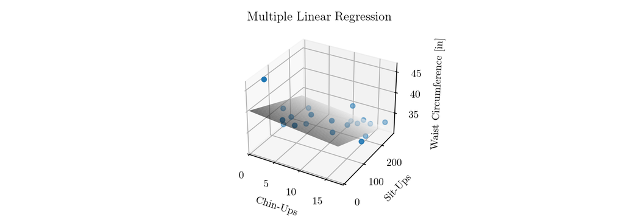

```python
def f(x, y):
    """
    Define the model as a function.

    z = α + β₁x + β₂y
    """
    return α + β1 * x + β2 * y


# Create plot
fig = plt.figure()
ax = fig.add_subplot(projection='3d')

# Scatter plot
#
# Independent variables
x = linnerud['data']['Chins']
y = linnerud['data']['Situps']
# Dependent variable
z = linnerud['target']['Waist']
# Scatter plot
ax.scatter(x, y, z)

# Surface plot
#
# Independent variables
x = np.linspace(0, linnerud['data']['Chins'].max(), 100)
y = np.linspace(0, linnerud['data']['Situps'].max(), 100)
X, Y = np.meshgrid(x, y)
# Dependent variable
Z = f(X, Y)
# Surface plot
ax.plot_surface(X, Y, Z, cmap='binary', alpha=0.6)

# Title and labels
ax.set_title('Multiple Linear Regression')
ax.set_xlabel('Chin-Ups')
ax.set_ylabel('Sit-Ups')
ax.set_zlabel('Waist Circumference [in]')

# Set the limits
xlim = ax.get_xlim()
ylim = ax.get_ylim()
ax.set_xlim(0, xlim[1])
ax.set_ylim(0, ylim[1])

plt.show()
```

# 6 Interpretation of the Results

As stated multiple times, the full multiple linear regression model is z = -0.121x - 0.026y + 40.317. The interpretation of this is that:

- 0.121 inches is the loss of waist circumference for each additional chin-up that someone can do
- 0.026 inches is the loss of waist circumference for each additional sit-up that someone can do
- 40.317 inches would be the waist circumference of someone who can do 0 chin-ups and 0 sit-ups. Of course, these values lie outside our range of observed data and so this statement constitutes **extrapolation**. Our model is not guaranteed to be robust enough to enable extrapolation. However, **interpolation** could be done to predict the waist circumference of someone who can do between 1 and 17 chin-ups and between 50 and 251 sit-ups (the minimum and maximum values we observed in our raw data)

The p-value associated with the chin-ups parameter is 0.441 which is larger than 0.1. This means we fail to reject the null hypothesis at the 0.1 significance level and acknowledge that β₁ might be equal to zero. In other words, the true effect of the number of chin-ups someone can do on their waist circumference is probably negligible. Possibly, this parameter could be removed from the model.

The 95% confidence intervals for each of the parameters can be used to generalise the model to the target population (middle-aged non-elite-athlete men). We can say that, for 95% of the target population, the relationship between their chin-ups, sit-ups and waist circumference numbers will fall within the bounds of the model’s confidence intervals.

⇦ Back